# When Does the Central Limit Theorem Work?

### 3.6.3 Histograms and Q–Q Plots

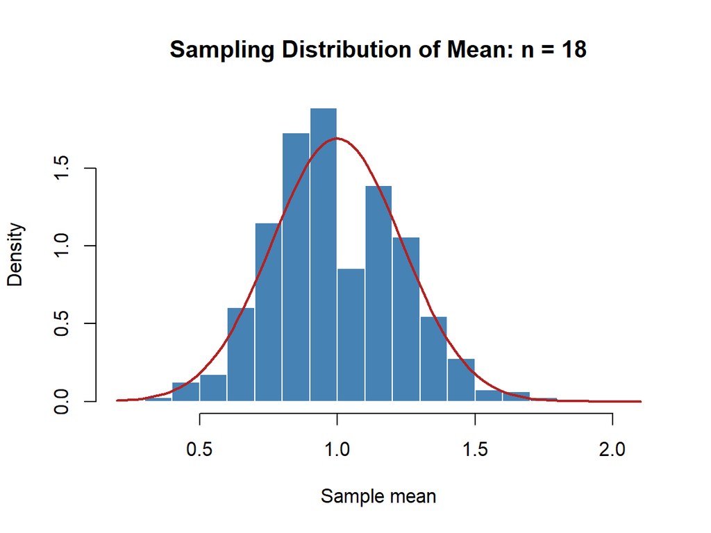

Figure 38: Histogram (left) and normal Q–Q plot (right) of the sample means at selected n.

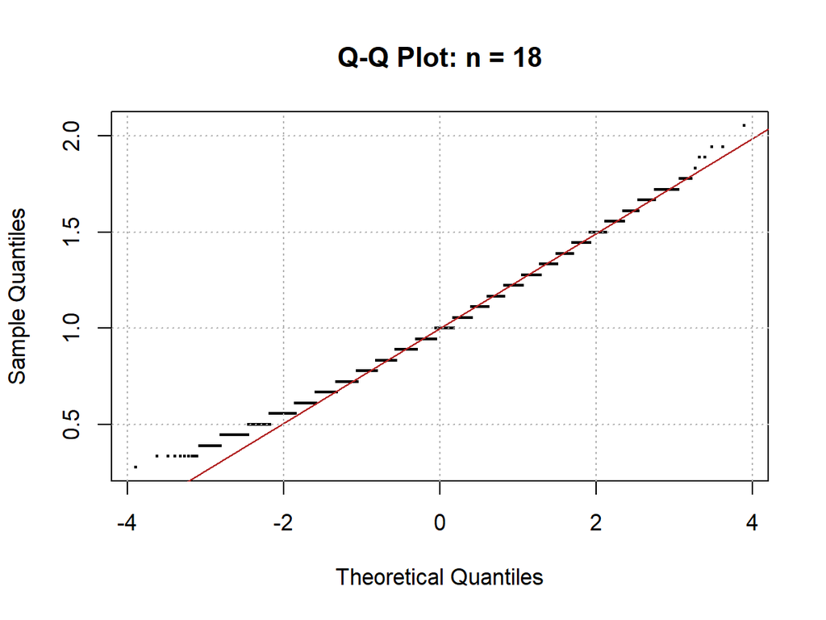

Figure 39: Histogram (left) and normal Q–Q plot (right) of the sample means at selected n.

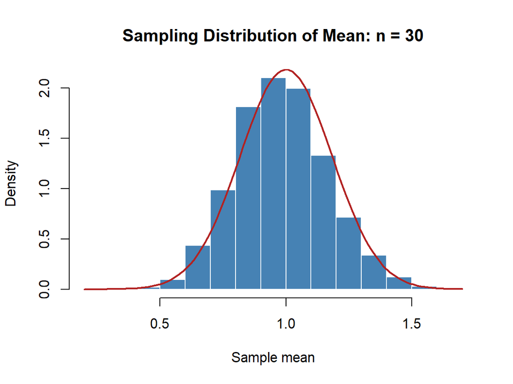

Figure 40: Histogram (left) and normal Q–Q plot (right) of the sample means at selected n.

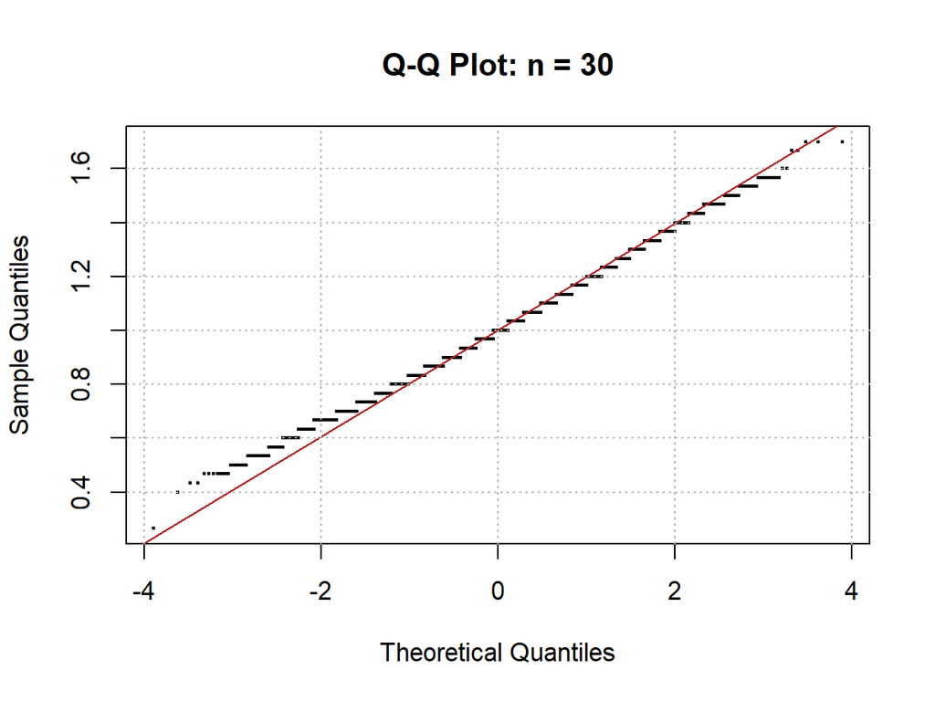

Figure 41: Histogram (left) and normal Q–Q plot (right) of the sample means at selected n.

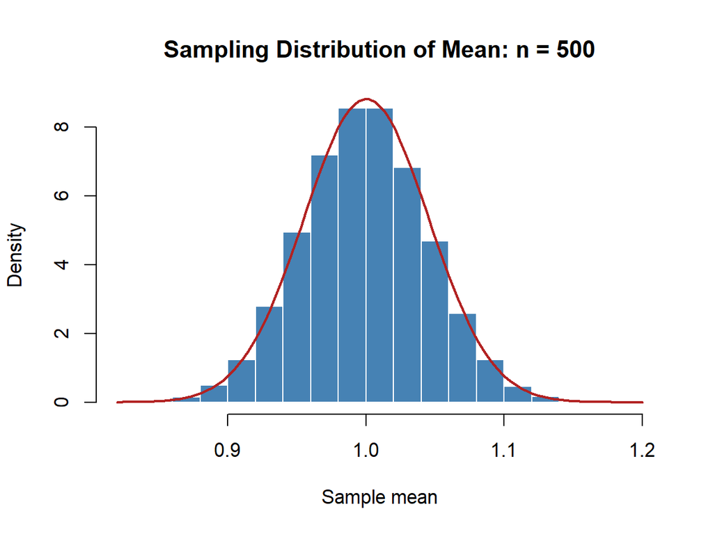

Figure 42: Histogram (left) and normal Q–Q plot (right) of the sample means at selected n.

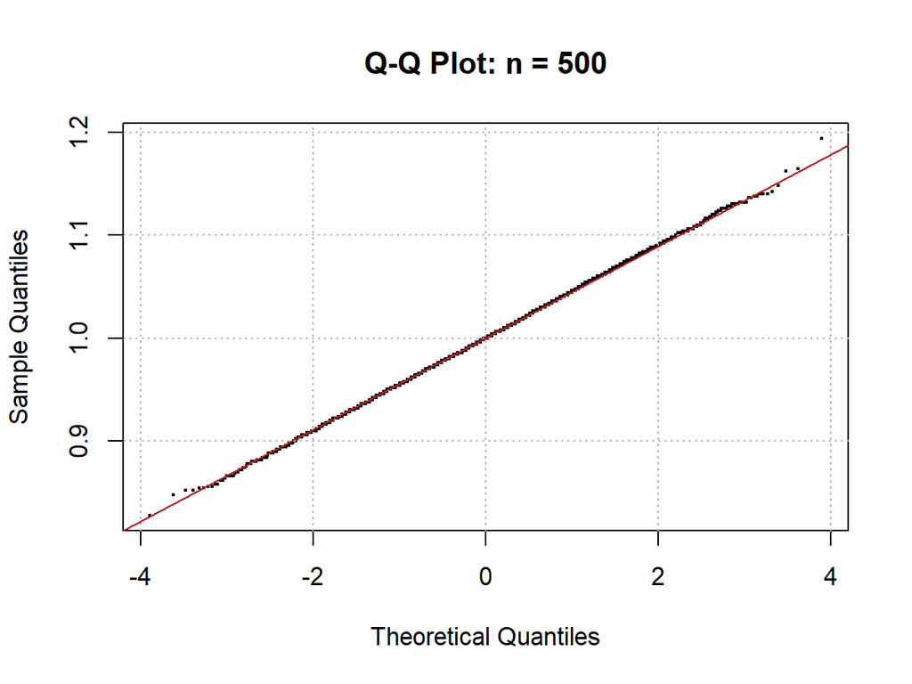

Figure 43: Histogram (left) and normal Q–Q plot (right) of the sample means at selected n.

```r
show_hist_qq("poisson")
```

The histograms are relatively close to the normal curve but do not smooth out until very high n, similar to the discrete six-sided die distribution.

The Q–Q plot shows left-tail divergence at n < 13. As n increase, the left tail starts converging to the normal straight line, but the right tail starts fluctuate away from the normal line. Visually, the data points follow the straight line relatively well around n ~ 18. The tails do fluctuate and/or converging slowly until n > 30.